# Reto_1_Matematicas_para_ML

## **Matemáticas para Machine Learning**

## **Reto 1**

### Diego Andres Burbano A.

\begin{equation} R(\theta)= \begin{bmatrix} \cos(\theta) & \sin(\theta) \\ -\sin(\theta) & \cos(\theta) \end{bmatrix} \end{equation}

**a) Muestre que su inversa es igual a su transpuesta:**

\begin{equation} R(\theta) ^ -1 = R(\theta)^T \end{equation}

Sea la matriz A: \begin{equation} A = \begin{bmatrix} a & b \\ c & d \end{bmatrix} \end{equation}

La inversa de A se calcula como: \begin{equation} A ^ {-1} = \frac {1}{Det(A)} \begin{bmatrix} d & -b \\ -c & a \end{bmatrix} (1) \end{equation}

y considerando que el determinante de R es igual a 1, ya que:

\begin{equation} Det(R(\theta)) = cos(\theta)*cos(\theta) - ( - sin(\theta)*sin(\theta)) \end{equation}

\begin{equation} Det(\theta)= cos(\theta)^2 + sin(\theta)^2 \end{equation}

Por identidad trigonométrica: \begin{equation} sin(\alpha)^2 + cos(\alpha)^2 = 1 \end{equation}

Por lo tanto se puede concluir que:

\begin{equation} Det(\theta)= 1 (2) \end{equation}

Por lo tanto aplicando (1) y (2) obtenemos: \begin{equation} R(\theta) ^{-1} = \begin{bmatrix} \cos(\theta) & -\sin(\theta) \\ \sin(\theta) & \cos(\theta) \end{bmatrix} (3) \end{equation}

Por definición, A transpuesta se calcula como: \begin{equation} A^{T} = \begin{bmatrix} a & c \\ b & d \end{bmatrix} \end{equation} Por lo tanto, \begin{equation} R(\theta)^{T}= \begin{bmatrix} \cos(\theta) & -\sin(\theta) \\ \sin(\theta) & \cos(\theta) \end{bmatrix} (4) \end{equation} De lo anterior, comparando (3) y (4) se puede deducir que: \begin{equation} R(\theta) ^ {-1} = R(\theta)^T \end{equation}

**b) Muestre que el determinante de R(theta) es igual a 1:**

Se demostró en el punto anterior. No obstante se presenta nuevamente la demostración:

El determinante de R es igual a 1, ya que:

\begin{equation} Det(R(\theta)) = cos(\theta)*cos(\theta) - ( - sin(\theta)*sin(\theta)) \end{equation}

\begin{equation} Det(\theta)= cos(\theta)^2 + sin(\theta)^2 \end{equation}

Por identidad trigonométrica: \begin{equation} sin(\alpha)^2 + cos(\alpha)^2 = 1 \end{equation}

Por lo tanto se puede concluir que:

\begin{equation} Det(\theta)= 1 \end{equation}

**c) Implemente un código en Python que reciba un vector de entrada 𝑥∈ℝ2 y un ángulo en radianes 𝜃, y devuelva el vector rotado. Además, este código debería graficar el vector original y el vector rotado (en colores diferentes).**

```python
import numpy as np
import matplotlib.pyplot as plt

def rotar_vector(x, theta):
    # Matriz de rotación
    R = np.array([[np.cos(theta), np.sin(theta)],
                  [-np.sin(theta), np.cos(theta)]])

    # Multiplicar la matriz por el vector
    x_rotado = np.dot(R, x)
    print(R)
    return x_rotado

def graficar_vectores(x, x_rotado):
    plt.axhline(0, color='black', linewidth=0.5)
    plt.axvline(0, color='black', linewidth=0.5)
    plt.grid(True, linestyle='--', linewidth=0.5)

    # Graficar el vector original en azul
    plt.quiver(0, 0, x[0], x[1], color='blue', angles='xy', scale_units='xy', scale=1, label='Original')
    # Graficar el vector rotado en rojo
    plt.quiver(0, 0, x_rotado[0], x_rotado[1], color='red', angles='xy', scale_units='xy', scale=1, label='Rotado')

    plt.xlim(-2, 2)
    plt.ylim(-2, 2)
    plt.legend()
    plt.show()
```

Se presentan varios ejemplos, dado un vector [1, 1] con ángulos de 30, 45 y 90 grados

```
[[ 0.8660254  0.5      ]
 [-0.5        0.8660254]]
```

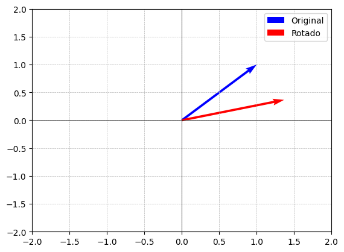

```python
x1 = np.array([1, 1])
theta = np.pi /6
x_rotado = rotar_vector(x1, theta)
graficar_vectores(x1, x_rotado)
#
```

```
[[ 0.70710678  0.70710678]
 [-0.70710678  0.70710678]]
```

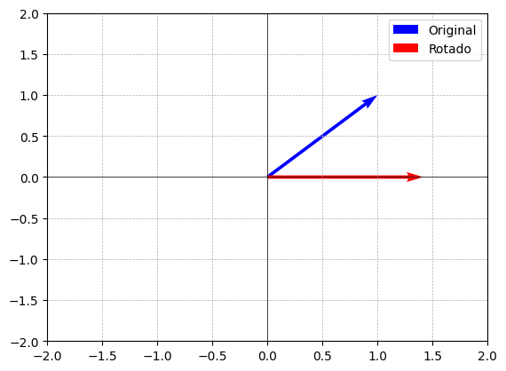

```python
x1 = np.array([1, 1])
theta = np.pi /4
x_rotado = rotar_vector(x1, theta)
graficar_vectores(x1, x_rotado)
#
```

[figure not shown]

```python
x1 = np.array([1, 1])
theta = np.pi /2
x_rotado = rotar_vector(x1, theta)
graficar_vectores(x1, x_rotado)
#
```

[output not shown]